# EmpatIA 2025 · kit de prensa

El Índice EmpatIA y el bloque de inteligencia artificial, con cada cifra lista para citar

Todas las cifras de este kit vienen con **su base y su margen**. Dos grupos cuyos rangos se pisan no son distintos, por grande que parezca la diferencia entre sus porcentajes. Cada ángulo arranca con **la pregunta textual del cuestionario** que lo produce, para que ninguna cifra se cite sin saber qué se preguntó. Al final hay una ficha técnica y una sección sobre qué **no** dice este estudio.

# Lo esencial

11,2de 100 es el Índice EmpatIA promedio de las marcas: cuánto se las asocia, en promedio, con cercanía y con tecnología entre quienes las conocenPromedio de 117 marcas · ±0,6 puntos · ▼ 1,5 puntos desde 2024

P18 ¿Has oído hablar de alguno de estos asistentes de Inteligencia Artificial, aunque sólo sea de nombre?

P19 Y aproximadamente, ¿Qué tanto utilizas estos asistentes?

P23 Y cuando necesitas resolver un problema, por ejemplo, reclamar por un cobro que no corresponde, ¿Qué canal prefieres?

51%de las personas usa algún asistente de inteligencia artificial al menos un par de veces al mesP18 + P19 · ±2,5 puntos

21%lo usa todos los días: para esa parte del país la inteligencia artificial ya es rutina, no una pruebaP18 + P19 · ±2,0 puntos

83%prefiere que lo atienda una persona cuando tiene que resolver un problemaP23 · ±1,9 puntos

# El Índice EmpatIA promedio

El Índice EmpatIA de una marca mide, entre quienes la conocen, cuánto se la asocia con cercanía y con tecnología, en una escala de 0 a 100. El promedio toma las 117 marcas del ranking 2025 y cuenta a cada una una vez, sea muy o poco conocida.

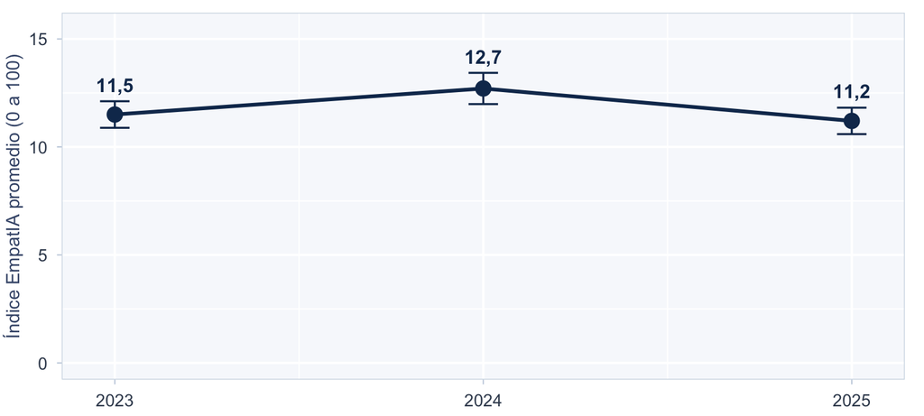

«En 2025, el Índice EmpatIA promedio de las marcas del estudio es de 11,2 sobre 100, 1,5 puntos menos que en 2024».

Es un promedio de marcas, no de personas: una marca de nicho pesa lo mismo que una masiva. Cada edición promedia las marcas de su propio ranking (113 en 2023, 110 en 2024, 117 en 2025), así que una parte de cualquier cambio puede venir de las marcas que entran o salen del listado. Un cambio dentro de ±0,6 puntos no se puede atribuir al mercado.

# Cuántas personas usan inteligencia artificial

Es la primera medición de este bloque: todavía no hay una edición anterior con la cual comparar.

| Grupo | % | Rango | Casos |
| --- | --- | --- | --- |
| 18 a 24 | 85 | 80 – 89 | 222 |
| 25 a 34 | 65 | 60 – 70 | 309 |
| 35 a 44 | 52 | 46 – 58 | 287 |
| 45 a 54 | 39 | 34 – 45 | 294 |
| 55 a 64 | 36 | 30 – 42 | 252 |
| 65 a 75 | 29 | 23 – 36 | 208 |

«Usa» significa aquí **al menos un par de veces al mes**, no haber probado alguna vez. Es un umbral de uso incorporado, y por eso la cifra es más baja que la de «ha usado alguna vez» que suelen reportar otros estudios.

# Conocer no es usar

P18 ¿Has oído hablar de alguno de estos asistentes de Inteligencia Artificial, aunque sólo sea de nombre?

P19 Y aproximadamente, ¿Qué tanto utilizas estos asistentes?

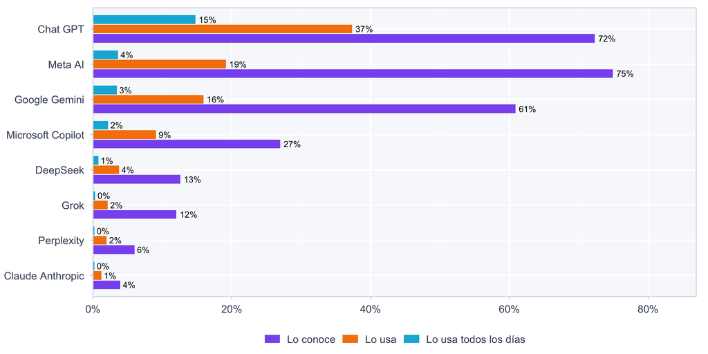

«Chat GPT es el asistente más usado del país: lo conoce el 72% de las personas y lo usa al menos un par de veces al mes el 37%. La distancia más grande entre conocer y usar la tiene Meta AI, con 56 puntos».

Las dos barras se leen **sobre la población total**. La frecuencia de uso solo se le pregunta a quien declara conocer el asistente, así que existe una segunda lectura —de cada cien que lo conocen, cuántos lo usan— que da cifras más altas. Está en la columna `usa_entre_conocedores_pct` del archivo de datos, y **no** es intercambiable con esta.

## Todos los días, marca por marca

P19 Y aproximadamente, ¿Qué tanto utilizas estos asistentes?

El uso diario es el peldaño más alto de P19 —«lo uso aproximadamente todos los días»— y el que separa a quien probó la herramienta de quien la incorporó.

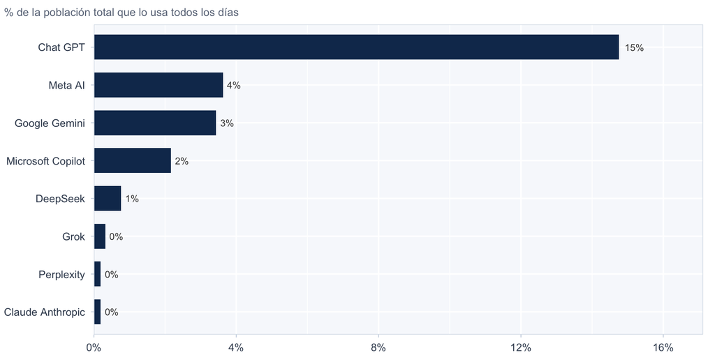

# La escalera de delegación

La edición 2025 no incluyó la pregunta sobre qué tareas se le han dejado a la inteligencia artificial, así que este ángulo no tiene cifras.

# La paciencia con la máquina se acaba cuando hay un problema

P21 Cuando necesitas un servicio de una marca, como por ejemplo cambiar una clave o consultar información, ¿Cuál de las siguientes alternativas representa mejor lo que prefieres hacer?

P23 Y cuando necesitas resolver un problema, por ejemplo, reclamar por un cobro que no corresponde, ¿Qué canal prefieres?

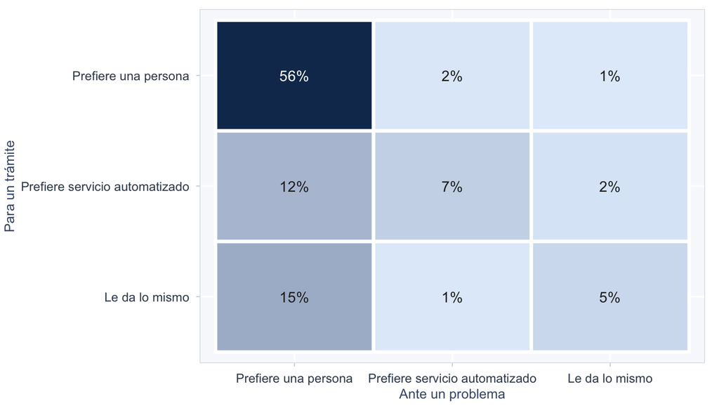

## Y vuelve al teléfono

P22 ¿Y qué canal de comunicación es el que prefiere para hacer ese contacto?

P24 ¿Y qué canal de comunicación es el que prefiere para hacer ese contacto?

Las dos preguntas están redactadas igual porque son la misma pregunta hecha dos veces: **P22** viene después del trámite de P21 y **P24**, después del problema de P23. Por eso la comparación es limpia —cambia la situación, no la pregunta—.

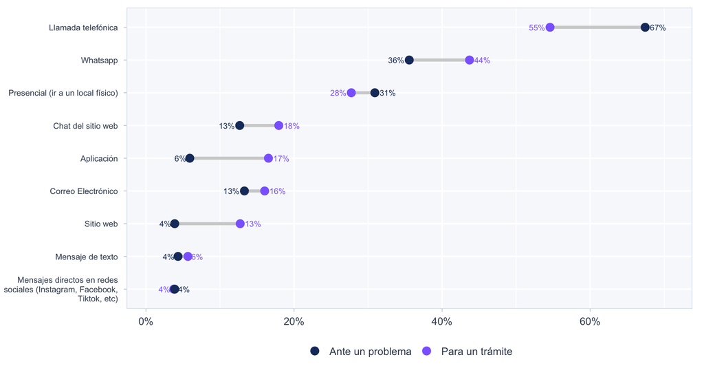

«Cuando aparece un problema, las personas vuelven al canal más antiguo. Llamada telefónica gana 13 puntos de preferencia respecto de un trámite corriente; Aplicación pierde 11. Lo digital sirve para gestionar; lo humano, para responder».

# Quien usa inteligencia artificial le pide otra cosa al servicio al cliente

El estudio le pregunta a la misma persona dos cosas: **qué asistentes usa** (P18 y P19) y **cómo quiere que la atienda una marca** (P21, P23 y P20). Con eso se puede partir al país en dos —quienes usan algún asistente al menos un par de veces al mes y quienes no— y mirar exactamente la misma pregunta en los dos grupos. Eso es lo que muestra el gráfico: cada línea es una exigencia, y los dos puntos son el mismo porcentaje calculado en cada grupo. Cuanto más larga la línea, más distinto contesta quien usa IA.

P18 ¿Has oído hablar de alguno de estos asistentes de Inteligencia Artificial, aunque sólo sea de nombre?

P19 Y aproximadamente, ¿Qué tanto utilizas estos asistentes?

P21 Cuando necesitas un servicio de una marca, como por ejemplo cambiar una clave o consultar información, ¿Cuál de las siguientes alternativas representa mejor lo que prefieres hacer?

P23 Y cuando necesitas resolver un problema, por ejemplo, reclamar por un cobro que no corresponde, ¿Qué canal prefieres?

P20 En una escala del 1 a 5, donde 1 es “Nada preocupado” y 5 es “Muy preocupado” ¿Qué tan preocupado(a) te sientes frente a los siguientes posibles impactos del uso de la inteligencia artificial?

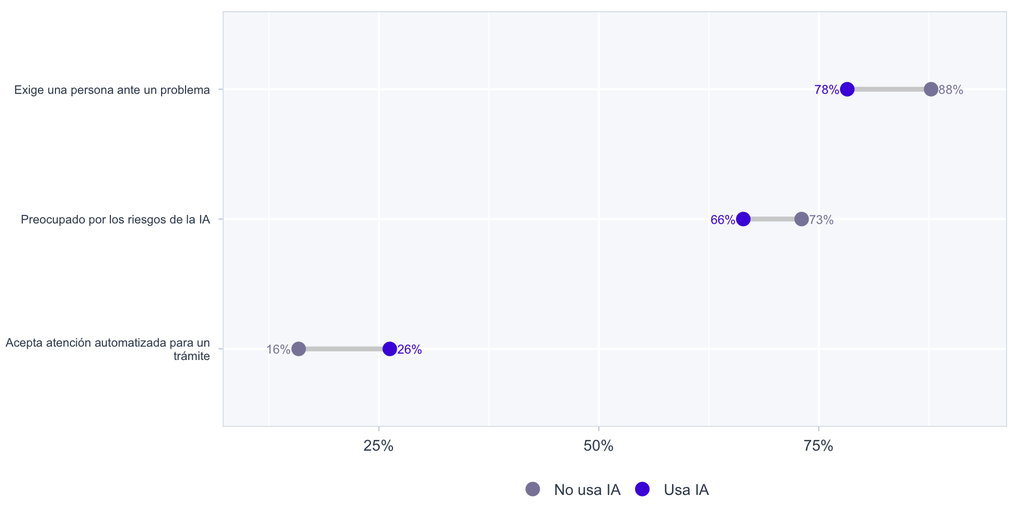

«Quien usa inteligencia artificial le exige cosas distintas a las marcas. En «acepta atención automatizada para un trámite», los usuarios están 10 puntos por encima de quienes no la usan: 26% contra 16%».

De 3 exigencias medidas, **3** distinguen de verdad a quien usa IA de quien no; el resto cabe dentro del margen. Una por una, las que se sostienen:

- **Acepta atención automatizada para un trámite**: 26% entre quienes usan IA y 16% entre quienes no la usan, 10 puntos más.
- **Exige una persona ante un problema**: 78% entre quienes usan IA y 88% entre quienes no la usan, 10 puntos menos.
- **Preocupado por los riesgos de la IA**: 66% entre quienes usan IA y 73% entre quienes no la usan, 7 puntos menos.

Puesto en una frase: **quien usa inteligencia artificial pide menos atención humana**. No es que le dé lo mismo —incluso entre quienes la usan, exigir una persona ante un problema sigue siendo mayoritario—, es que el piso de tolerancia a lo automatizado es otro.

Esta es una **asociación, no una causa**. Quien usa IA y quien no usa IA se diferencian también en edad y en otras cosas, y este cruce no las descuenta. No se puede decir que usar IA *vuelva* a la gente más tolerante con los bots: puede ser al revés, o puede ser la edad detrás de las dos cosas. Lo que el estudio sostiene es que los dos rasgos van juntos.

# Entre personalización y privacidad

La edición 2025 no incluyó la pregunta que obliga a elegir entre personalización y privacidad, así que este ángulo no tiene cifras.

# Usar y desconfiar no son opuestos

P18 ¿Has oído hablar de alguno de estos asistentes de Inteligencia Artificial, aunque sólo sea de nombre?

P19 Y aproximadamente, ¿Qué tanto utilizas estos asistentes?

P20 En una escala del 1 a 5, donde 1 es “Nada preocupado” y 5 es “Muy preocupado” ¿Qué tan preocupado(a) te sientes frente a los siguientes posibles impactos del uso de la inteligencia artificial?

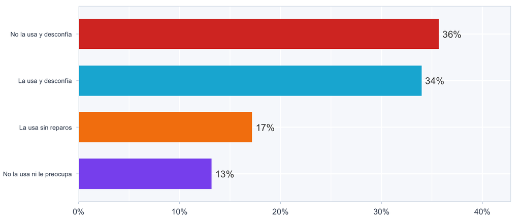

«Usar inteligencia artificial y desconfiar de ella no se excluyen: el 34% de las personas hace las dos cosas. El grupo más numeroso, con el 36%, es el que no la usa y desconfía».

Se considera preocupada a la persona que declara inquietud alta en **la mitad o más** de los riesgos consultados, no en uno solo. Con un umbral de un solo riesgo la cifra sería mucho más alta y diría mucho menos.

# El costo ambiental

La edición 2025 no incluyó las frases sobre el costo ambiental de la inteligencia artificial, así que este ángulo no tiene cifras.

# Lo que esto le pide a las marcas

La edición 2025 no incluyó atributos de **IA responsable** para las marcas, así que este ángulo no tiene cifras.

# Las diferencias más grandes del estudio

Para una nota, la distancia entre dos grupos suele ser más interesante que el total. Estas son las mayores, ya filtradas: **solo aparecen las que superan el margen conjunto de los dos grupos comparados**. Como cada fila viene de un ángulo distinto, la pregunta que la produce va en su propia columna; el texto completo de cada una está en el ángulo correspondiente, más arriba.

| Indicador | Pregunta | Corte | Más alto | Más bajo | Brecha |
| --- | --- | --- | --- | --- | --- |
| Usa al menos un asistente de IA al menos un par… | P18 + P19 | Tramo de edad | 18 a 24 (85%) | 65 a 75 (29%) | 55 pp |
| Usa IA y a la vez desconfía de ella | P18 + P19 + P20 | Tramo de edad | 18 a 24 (60%) | 65 a 75 (20%) | 40 pp |
| Usa algun asistente de IA todos los dias | P18 + P19 | Tramo de edad | 18 a 24 (43%) | 65 a 75 (7%) | 36 pp |
| Usa dos o mas asistentes de IA | P18 + P19 | Tramo de edad | 18 a 24 (45%) | 65 a 75 (10%) | 36 pp |
| Usa al menos un asistente de IA al menos un par… | P18 + P19 | Generacion | Menores de 45 (66%) | 45 o mas (35%) | 30 pp |
| Prefiere ser atendido por una persona ante un p… | P23 | Tramo de edad | 65 a 75 (91%) | 18 a 24 (69%) | 22 pp |
| Usa algun asistente de IA todos los dias | P18 + P19 | Generacion | Menores de 45 (30%) | 45 o mas (10%) | 20 pp |
| Usa IA y a la vez desconfía de ella | P18 + P19 + P20 | Generacion | Menores de 45 (44%) | 45 o mas (24%) | 20 pp |
| Prefiere atencion automatizada para un tramite | P21 | Tramo de edad | 25 a 34 (30%) | 65 a 75 (12%) | 19 pp |
| Usa dos o mas asistentes de IA | P18 + P19 | Generacion | Menores de 45 (33%) | 45 o mas (15%) | 18 pp |
| Usa al menos un asistente de IA al menos un par… | P18 + P19 | GSE | ABC1 (59%) | D/E (44%) | 16 pp |
| Conoce al menos un asistente de IA | P18 | Tramo de edad | 18 a 24 (98%) | 65 a 75 (83%) | 16 pp |

# Qué NO dice este estudio

- **No mide comportamiento, mide declaración.** Todo lo anterior es lo que las personas dicen que hacen y prefieren. Es lo que una encuesta puede medir, y no es lo mismo que observar la conducta.
- **No establece causas.** Los cruces de este kit muestran que dos cosas van juntas, no que una produzca la otra.
- **No cubre a toda la población.** La muestra es de personas de 18 a 75 años con acceso a internet. Quien no está en línea no está aquí, y para un tema como este esa exclusión no es neutral.
- **Una medición no es una tendencia.** Es la primera medición del bloque: dice cómo está el país hoy, no hacia dónde va.
- **Las diferencias pequeñas no son diferencias.** Cada cifra trae su rango. Si dos rangos se pisan, el estudio no sostiene que los grupos sean distintos.

# Ficha técnica

**Estudio EmpatIA 2025**, de dobleA y Better Brands. Estudio anual sobre cómo las marcas equilibran humanidad y tecnología para conectar con las personas en Chile.

**Atribución sugerida:** «Estudio EmpatIA 2025, de dobleA y Better Brands».

**Consultas:** contacto@dobleachile.cl · contacto@betterbrands.cl